# pochodne_numeryczne

## Pochodne numeryczne

Numeryczne różniczkowanie - znalezienie pochodnej f(x) w punkcie $x=x_k$, może dotyczyć zagadnienia

\begin{itemize} \item znamy algorytm obliczania f(x) \item mamy dostęp do skończonej liczby danych $(x_i,y_i), \;\;i=0,1,\ldots,n$ \end{itemize}

Różniczkowanie metodą różnic skończonych w równodległych punktach

W tej metodzie wykorzystuje się rozwinięcia w szeregi Taylora $f(x\pm h), \; f(x\pm 2h), \ldots$

$$ f(x\pm h)=f(x)\pm h f^{\prime}(x)+\frac{h^2}{2}f^{\prime\prime}(x) +\frac{h^3}{6}f^{\prime\prime\prime}(x)+\ldots $$

### Obliczanie pochodnych w przybliżeniu różnicy centralnej

Pierwsza pochodna w przybliżeniu różnicy centralnej

Z różnicy $f(x+h)-f(x-h)$ otrzymamy wyrażenie na pierwszą pochodną rzędu $h^2$

$$ f^{\prime}(x)=\frac{f(x+h)-f(x-h)}{2h}+\frac{h^2}{6}f^{\prime\prime\prime}(x)+\ldots =\frac{f(x+h)-f(x-h)}{2h}+\mathcal{O}(h^2) $$\begin{textboxa} Pierwsza pochodna rzędu $h^2$ w przybliżeniu różnicy centralnej \end{textboxa}$$ f^{\prime}(x)=\frac{f(x+h)-f(x-h)}{2h}+\mathcal{O}(h^2) $$

W podobny sposób, $f(x+h)+f(x-h)-2f(x)$, otrzymuje się wyrażenie na

\begin{textboxa} drugą pochodną rzędu $h^2$ w przybliżeniu różnicy centralnej \end{textboxa}$$ f^{\prime\prime}(x)=\frac{f(x+h)+f(x-h)-2f(x)}{h^2}+\mathcal{O}(h^2) $$

Wyrażenia na pierwszą i drugą pochodną rzędu $h^4$ korzystają z 5 punktów

\begin{textboxa} Pierwsza pochodna rzędu $h^4$ w przybliżeniu różnicy centralnej \end{textboxa}$$ f^{\prime}(x)=\frac{f(x-2h)-8f(x-h)+8f(x+h)-f(x+2h)}{12h}+\mathcal{O}(h^4) $$\begin{textboxa} Druga pochodna rzędu $h^4$ w przybliżeniu różnicy centralnej \end{textboxa}$$ f^{\prime\prime}(x)=\frac{-f(x-2h)+16f(x-h)-30f(x)+16f(x+h)-f(x+2h)}{12h^2}+\mathcal{O}(h^4) $$

Wagi dla n-tej pochodnej w m-punktowym przybliżeniu różnicy centralnej możemy dostać z funkcji central_diff_weights(m,n)

https://docs.scipy.org/doc/scipy/reference/generated/scipy.misc.central_diff_weights.html#scipy.misc.central_diff_weights

```python
from scipy.misc import central_diff_weights as cdw
# wagi dla pierwszej  pochodnej 3-punktowej
w1= cdw(3,1)
# h*f'(x)=w1[0]*f(x-h)+w[1]*f(x)+w[2]*f(x+h)
print( w1)
```

```
[-0.5  0.   0.5]
```

```python
# wagi dla pierwszej  pochodnej 5-punktowej
w1= cdw(5,1)
# h*f'(x)=w1[0]*f(x-2h)+w[1]*f(x-h)+w[2]*f(x)+w[3]*f(x+h)+w[4]*f(x+2h)
print( w1)
print( 12*w1)
```

```
[ 0.08333333 -0.66666667  0.          0.66666667 -0.08333333]
[ 1. -8.  0.  8. -1.]
```

```python
# wagi dla drugiej  pochodnej 5-punktowej
w2= cdw(5,2)
# h**2*f''(x)=w1[0]*f(x-2h)+w[1]*f(x-h)+w[2]*f(x)+w[3]*f(x+h)+w[4]*f(x+2h)
print( w2)
print( 12*w2)
```

```
[-0.08333333  1.33333333 -2.5         1.33333333 -0.08333333]
[ -1.  16. -30.  16.  -1.]
```

Zastosujemy teraz wzory na pierwszą i drugą pochodną dla funkcji $f(x)=sin(1/x)$

```python
# funkcja sin(1/x) i jej pierwsza i druga pochodna
import numpy as np
def f(x):
    return np.sin(1.0/x)
def p1f(x):
    return -np.cos(1.0/x)/x**2
def p2f(x):
    return -np.sin(1.0/x)/x**4+2*np.cos(1.0/x)/x**3
```

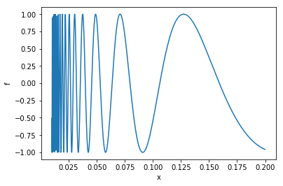

```python
# wykres f(x)
%matplotlib  inline
import matplotlib.pyplot as plt

zx = np.arange(0.01, 0.2, 0.0001)
plt.plot(zx,f(zx))
plt.xlabel('x')
plt.ylabel('f')
plt.show()
```

```python
# Obliczenie pierwszej pochodnej w x=0.05 za pomocą przybliżenia 3 i 5-punktowego  róznicy centralnej
x=0.05

h=1e-2
p1_ex=p1f(x)
# wynik dokładny
print('p1_ex=%16.12f'%(p1_ex))
# pętla po h=1e-3, 1e-4, 1e-5, 1e-6
for _ in range(4):
    h/=10
    print('\nh=',h)
    np1_3=(-0.5*f(x-h)+0.5*f(x+h))/h
    np1_5=(f(x-2*h)-8*f(x-h)+8*f(x+h)-f(x+2*h))/(12*h)

    print('np1_3=%16.12f  bl=%16.12f'%(np1_3,p1_ex-np1_3))
    print('np1_5=%16.12f  bl=%16.12f'%(np1_5,p1_ex-np1_5))
```

```
p1_ex=-163.232824725357

h= 0.001
np1_3=-156.123383898086  bl= -7.109440827270
np1_5=-162.841052894599  bl= -0.391771830757

h= 0.0001
np1_3=-163.160744651948  bl= -0.072080073408
np1_5=-163.232784745529  bl= -0.000039979828

h= 1e-05
np1_3=-163.232103825711  bl= -0.000720899646
np1_5=-163.232824721433  bl= -0.000000003924

h= 1.0000000000000002e-06
np1_3=-163.232817516679  bl= -0.000007208678
np1_5=-163.232824725792  bl=  0.000000000435
```

```python
# wagi dla drugiej  pochodnej w przybliżeniu 5-punktowym
w2= cdw(5,2)
# h**2*f''(x)=w1[0]*f(x-2h)+w[1]*f(x-h)+w[2]*f(x)+w[3]*f(x+h)+w[4]*f(x+2h)
print( w2)
print( 12*w2)
```

```
[-0.08333333  1.33333333 -2.5         1.33333333 -0.08333333]
[ -1.  16. -30.  16.  -1.]
```

```python
# Obliczenie drugiej pochodnej w x=0.05 za pomocą przybliżenia 3 i 5-punktowego  róznicy centralnej
h=1e-2
p2_ex=p2f(x)
# wynik dokładny
print('p2_ex=%16.12f'%(p2_ex))
# pętla po h=1e-3, 1e-4, 1e-5, 1e-6
for _ in range(4):
    h/=10
    print('\nh=',h)
    np2_3=(f(x-h)-2*f(x)+f(x+h))/h**2
    np2_5=(-f(x-2*h)+16*f(x-h)-30*f(x)+16*f(x+h)-f(x+2*h))/(12*h**2)

    print('np2_3=%16.12f  bl=%16.12f'%(np2_3,p2_ex-np2_3))
    print('np2_5=%16.12f  bl=%16.12f'%(np2_5,p2_ex-np2_5))
```

```
p2_ex=-139541.927127406147

h= 0.001
np2_3=-138285.838719230058  bl=-1256.088408176089
np2_5=-139554.861055773072  bl= 12.933928366925

h= 0.0001
np2_3=-139529.400794657908  bl=-12.526332748239
np2_5=-139541.928548394149  bl=  0.001420988003

h= 1e-05
np2_3=-139541.801879028411  bl= -0.125248377735
np2_5=-139541.927140958869  bl=  0.000013552723

h= 1.0000000000000002e-06
np2_3=-139541.926791331090  bl= -0.000336075056
np2_5=-139541.928243872884  bl=  0.001116466738
```

Dokładność numerycznego obliczenia pochodnej f(x) metodą różnic skończonych jest zwykle mniejsza niż dokładność obliczenia f(x). Z wzorów na pochodną, np. rzędu $h^2$, wynika, iż im mniejsze h tym mniejszy błąd obliczonej pochodnej. Jednak dla bardzo małych h może nastąpić utrata cyfr znaczących ponieważ w wyrażeniach na pochodne wystęouje odejmowanie bliskich sobie wielkości, np. $f(x+h)-f(x-h)$. Dlatego też nie powinno się brać zbyt małego kroku h. Sprawdzimy teraz jakie jest optymalne h przy obliczaniu pierwszej i drugiej pochodnej metodą róznicy centralnej korzystając z funkcji derivative() z scipy.mix

https://docs.scipy.org/doc/scipy/reference/generated/scipy.misc.derivative.html#scipy.misc.derivative

```python
# 3-punktowe przybliżenie pierwszej pochodnej w x=0.05
from scipy.misc import derivative
x0=0.05
h=0.10
ep1=p1f(x0)
for i in range(14):
    h/=10
    np1=derivative(f, x0, dx=h,order=3)
    print("h=%7.1e   f'=%16.12f   df'=%13.6e" %(h,np1,ep1-np1))
```

```
h=1.0e-02   f'=-34.304775153009   df'=-1.289280e+02
h=1.0e-03   f'=-156.123383898086   df'=-7.109441e+00
h=1.0e-04   f'=-163.160744651948   df'=-7.208007e-02
h=1.0e-05   f'=-163.232103825711   df'=-7.208996e-04
h=1.0e-06   f'=-163.232817516679   df'=-7.208678e-06
h=1.0e-07   f'=-163.232824653692   df'=-7.166497e-08
h=1.0e-08   f'=-163.232824751391   df'= 2.603466e-08
h=1.0e-09   f'=-163.232825201032   df'= 4.756750e-07
h=1.0e-10   f'=-163.232831140725   df'= 6.415368e-06
h=1.0e-11   f'=-163.232838357175   df'= 1.363182e-05
h=1.0e-12   f'=-163.232871663865   df'= 4.693851e-05
h=1.0e-13   f'=-163.239977091223   df'= 7.152366e-03
h=1.0e-14   f'=-163.175029044282   df'=-5.779568e-02
h=1.0e-15   f'=-163.091762317435   df'=-1.410624e-01
```

Widzimy, że najlepsze 3-punktowe przybliżenie pierwszej pochodnej w x=0.05 otrzymaliśmy dla $h=10^{-8}$. Gdy $h<10^{-12}$ obserwujemy szybki wzrost błędu przy zmniejszaniu h.

Teraz przetestujemy 3-punktowe przybliżenie pierwszej pochodnej w x=0.5, w otoczeniu którego funkcja jest wolnozmienna.

```python
x0=0.5
h=0.10
ep1=p1f(x0)
for i in range(14):
    h/=10
    np1=derivative(f, x0, dx=h,order=3)
    print("h=%7.1e   f'=%16.12f   df'=%13.6e" %(h,np1,ep1-np1))
```

```
h=1.0e-02   f'=  1.667719830469   df'=-3.132484e-03
h=1.0e-03   f'=  1.664618663235   df'=-3.131705e-05
h=1.0e-04   f'=  1.664587659358   df'=-3.131694e-07
h=1.0e-05   f'=  1.664587349315   df'=-3.126280e-09
h=1.0e-06   f'=  1.664587346184   df'= 4.548806e-12
h=1.0e-07   f'=  1.664587346295   df'=-1.064733e-10
h=1.0e-08   f'=  1.664587345740   df'= 4.486380e-10
h=1.0e-09   f'=  1.664587356842   df'=-1.065359e-08
h=1.0e-10   f'=  1.664587356842   df'=-1.065359e-08
h=1.0e-11   f'=  1.664590687511   df'=-3.341323e-06
h=1.0e-12   f'=  1.664557380820   df'= 2.996537e-05
h=1.0e-13   f'=  1.665334536938   df'=-7.471907e-04
h=1.0e-14   f'=  1.665334536938   df'=-7.471907e-04
h=1.0e-15   f'=  1.665334536938   df'=-7.471907e-04
```

W x=0.5 najlepsze 3-punktowe przybliżenie pierwszej pochodnej otrzymaliśmy dla $h=10^{-6}$.

Teraz przetestujemy 5-punktowe przybliżenie pierwszej pochodnej w x=0.05.

```python
x0=0.05
h=0.10
ep1=p1f(x0)
for i in range(14):
    h/=10
    np1=derivative(f, x0, dx=h,order=5)
    print("h=%7.1e   f'=%16.12f   df'=%13.6e" %(h,np1,ep1-np1))
```

```
h=1.0e-02   f'=-46.143513038102   df'=-1.170893e+02
h=1.0e-03   f'=-162.841052894599   df'=-3.917718e-01
h=1.0e-04   f'=-163.232784745528   df'=-3.997983e-05
h=1.0e-05   f'=-163.232824721440   df'=-3.916369e-09
h=1.0e-06   f'=-163.232824725676   df'= 3.191190e-10
h=1.0e-07   f'=-163.232824726966   df'= 1.609749e-09
h=1.0e-08   f'=-163.232824754167   df'= 2.881023e-08
h=1.0e-09   f'=-163.232825312054   df'= 5.866973e-07
h=1.0e-10   f'=-163.232833083615   df'= 8.358258e-06
h=1.0e-11   f'=-163.232835581617   df'= 1.085626e-05
h=1.0e-12   f'=-163.232954930592   df'= 1.302052e-04
h=1.0e-13   f'=-163.243307760297   df'= 1.048303e-02
h=1.0e-14   f'=-163.161151256475   df'=-7.167347e-02
h=1.0e-15   f'=-162.994617802781   df'=-2.382069e-01
```

Najlepsze 5-punktowe przybliżenie pierwszej pochodnej w x=0.05 otrzymaliśmy dla $h=10^{-6}$.

Sprawdzimy jeszcze to przybliżenie pochodnej w x=0.5.

```python
x0=0.5
h=0.10
ep1=p1f(x0)
for i in range(14):
    h/=10
    np1=derivative(f, x0, dx=h,order=5)
    print("h=%7.1e   f'=%16.12f   df'=%13.6e" %(h,np1,ep1-np1))
```

```
h=1.0e-02   f'=  1.664584209581   df'= 3.136608e-06
h=1.0e-03   f'=  1.664587345873   df'= 3.153833e-10
h=1.0e-04   f'=  1.664587346189   df'=-3.108624e-14
h=1.0e-05   f'=  1.664587346176   df'= 1.287548e-11
h=1.0e-06   f'=  1.664587346129   df'= 6.005996e-11
h=1.0e-07   f'=  1.664587346295   df'=-1.064733e-10
h=1.0e-08   f'=  1.664587355454   df'=-9.265813e-09
h=1.0e-09   f'=  1.664587412353   df'=-6.616474e-08
h=1.0e-10   f'=  1.664586246619   df'= 1.099569e-06
h=1.0e-11   f'=  1.664580973060   df'= 6.373129e-06
h=1.0e-12   f'=  1.664446358518   df'= 1.409877e-04
h=1.0e-13   f'=  1.665334536938   df'=-7.471907e-04
h=1.0e-14   f'=  1.665334536938   df'=-7.471907e-04
h=1.0e-15   f'=  1.706967900361   df'=-4.238055e-02
```

Powyższe testy wykazały, że optymalne wartości korku h do przybliżonego obliczenia pierwszej pochodnej mogą zależeć od punktu, w którym pochodna jest obliczana oraz od rodzaju przybliżenia.

```python
# Testujemy wielkość h do obliczenia drugiej pochodnej w przybliżeniu 3-punktowym w x=0.05
x=0.05
h=0.10
ep2=p2f(x)
for i in range(9):
    h/=10
    np2_3=derivative(f, x, dx=h,n=2,order=3)
    print("h=%7.1e   f''=%16.12f   df''=%13.6e   df''/f''=%13.6e" %(h,np2_3,ep2-np2_3,(ep2-np2_3)/np2_3))
```

```
h=1.0e-02   f''=-27766.895047109712   df''=-1.117750e+05   df''/f''= 4.025478e+00
h=1.0e-03   f''=-138285.838719230058   df''=-1.256088e+03   df''/f''= 9.083276e-03
h=1.0e-04   f''=-139529.400794657908   df''=-1.252633e+01   df''/f''= 8.977558e-05
h=1.0e-05   f''=-139541.801879028411   df''=-1.252484e-01   df''/f''= 8.975689e-07
h=1.0e-06   f''=-139541.926791331090   df''=-3.360751e-04   df''/f''= 2.408416e-09
h=1.0e-07   f''=-139542.066790454497   df''= 1.396630e-01   df''/f''=-1.000867e-06
h=1.0e-08   f''=-139547.262634209765   df''= 5.335507e+00   df''/f''=-3.823441e-05
h=1.0e-09   f''=-140221.168010157213   df''= 6.792409e+02   df''/f''=-4.844068e-03
h=1.0e-10   f''=-299760.216648792091   df''= 1.602183e+05   df''/f''=-5.344882e-01
```

```python
# Testujemy wielkość h do obliczenia drugiej pochodnej w przybliżeniu 5-punktowym w x=0.05
x=0.05
h=0.10
ep2=p2f(x)
for i in range(9):
    h/=10
    np2_5=derivative(f, x, dx=h,n=2,order=5)
    print("h=%7.1e   f''=%16.12f   df''=%13.6e   df''/f''=%13.6e" %(h,np2_3,ep2-np2_5,(ep2-np2_5)/np2_5))
```

```
h=1.0e-02   f''=-299760.216648792091   df''=-1.024330e+05   df''/f''= 2.760338e+00
h=1.0e-03   f''=-299760.216648792091   df''= 1.293393e+01   df''/f''=-9.267988e-05
h=1.0e-04   f''=-299760.216648792091   df''= 1.420994e-03   df''/f''=-1.018328e-08
h=1.0e-05   f''=-299760.216648792091   df''= 1.503300e-05   df''/f''=-1.077311e-10
h=1.0e-06   f''=-299760.216648792091   df''= 1.259871e-03   df''/f''=-9.028616e-09
h=1.0e-07   f''=-299760.216648792091   df''= 2.062764e-01   df''/f''=-1.478238e-06
h=1.0e-08   f''=-299760.216648792091   df''= 7.278397e+00   df''/f''=-5.215649e-05
h=1.0e-09   f''=-299760.216648792091   df''= 9.567966e+02   df''/f''=-6.810002e-03
h=1.0e-10   f''=-299760.216648792091   df''= 2.296072e+05   df''/f''=-6.219904e-01
```

W tym przykładzie największą dokładność drugiej pochodnej dostajemy dla $h=10^{-5}$. Widzimy też efekt nie występujący przy obliczaniu pierwszej pochodnej. Dla $h<10^{-8}$ pojawiają się oblrzymie błędy bezwzględne!

```python
# Testujemy wielkość h do obliczenia drugiej pochodnej w przybliżeniu 3-punktowym w x=0.5
x=0.5
h=0.10
ep2=p2f(x)
for i in range(8):
    h/=10
    np2_3=derivative(f, x, dx=h,n=2,order=3)
    print("h=%7.1e   f''=%16.12f   df''=%13.6e   df''/f''=%13.6e" %(h,np2_3,ep2-np2_3,(ep2-np2_3)/np2_3))
```

```
h=1.0e-02   f''=-21.219962199669   df''= 1.285399e-02   df''/f''=-6.057497e-04
h=1.0e-03   f''=-21.207236767129   df''= 1.285532e-04   df''/f''=-6.061759e-06
h=1.0e-04   f''=-21.207109490717   df''= 1.276752e-06   df''/f''=-6.020397e-08
h=1.0e-05   f''=-21.207109401900   df''= 1.187934e-06   df''/f''=-5.601585e-08
h=1.0e-06   f''=-21.207036127180   df''=-7.208679e-05   df''/f''= 3.399192e-06
h=1.0e-07   f''=-21.216362000587   df''= 9.253787e-03   df''/f''=-4.361627e-04
h=1.0e-08   f''=-19.984014443253   df''=-1.223094e+00   df''/f''= 6.120361e-02
h=1.0e-09   f''=-222.044604925031   df''= 2.008375e+02   df''/f''=-9.044917e-01
```

### Obliczanie pochodnych w punktach brzegowych

W przypadku gdy mamy podane wartości funkcji w punktach $x_0, x_1,\dots,x_{n-1},x_n$ i chcemy obliczyć pochodną w punktach brzegowych, to nie możemy posłużyć się metodą różnic centralnych. W tym przypadku możemy użyć wzorów m-punktowych "w przód" i "w tył"

Wzór dwupunktowy w przód rzędu h $$ f^{\prime}(x)=\frac{f(x+h)-f(x)}{h}+\mathcal{O}(h) $$

Wzór trójpunktowy w przód rzędu $h^2$

$$ f^{\prime}(x)=\frac{-f(x+2h)+4f(x+h)-3f(x)}{2h}+\mathcal{O}(h^2) $$

Wzór dwupunktowy w tył rzędu h $$ f^{\prime}(x)=\frac{f(x)-f(x-h)}{h}+\mathcal{O}(h) $$

Wzór trójpunktowy w tył rzędu $h^2$

$$ f^{\prime}(x)=\frac{3f(x)-4f(x-h) +f(x-2h)}{2h}+\mathcal{O}(h^2) $$

```python
#przykład
xi=np.array([0,0.05,0.1,0.15,0.2])
fi=np.array([0,0.04988,0.099,0.14666,0.19216])
h=0.05
# w x=0
p1_p=(-fi[2]+4*fi[1]-3*fi[0])/(2*h)
print('x=',xi[0]," f'=",p1_p)

# w x=0.2
p1_t=(3*fi[4]-4*fi[3]+fi[2])/(2*h)
print('x=',xi[4]," f'=",p1_t)
```

```
x= 0.0  f'= 1.0051999999999999
x= 0.2  f'= 0.8883999999999994
```

### Obliczanie pochodnych w nierównoodległych punktach.

Numeryczne obliczanie pochodnych, gdy punkty $x_i$ nie są równoodległe. Można znaleźć funkcję interpolująca lub aproksymującą i następnie ją zróżniczkować.

Do rózniczkowania wielomianu możemy użyć funkcji polyder z modułu numpy

https://docs.scipy.org/doc/numpy/reference/generated/numpy.polyder.html

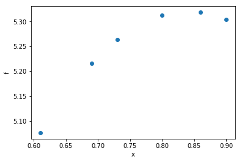

```python
# Przykład
t=np.array([0.61,0.69,0.73,0.8, 0.86, 0.9])
z=np.array([5.07672964, 5.21648459, 5.26413855, 5.31229678, 5.31828986, 5.30441388])

plt.plot(t,z,'o')
plt.xlabel('x')
plt.ylabel('f')
plt.show()
```

```python
# Zastosujemy  interpolację Lagranża, cubic splines i dopasowanie wielomianem 3 stopnia.
# Wykorzystamy numpy.polyder do obliczenia pochodnych wielomianu
# oraz metodę obliczenia pochodnych dla CubicSpline


from scipy.interpolate import lagrange
from scipy.interpolate import CubicSpline
# Dane z nierównoodległymi węzłami

wl = lagrange(t, z)
print('wl=')
print(wl)
pwl=np.polyder(wl)
# interpolacja CubicSpline
tcs = CubicSpline(t, z)
# fitowanie wielomianem 3. stopnia
fw2 = np.polyfit(t,z, 3)
print('\nwf=')
print(np.poly1d(fw2) )
pfw2=np.polyder(np.poly1d(fw2))

print('\npwl:',pwl(t))
print('pcs:',tcs(t,1))
print('pwf:',pfw2(t))
```

```
wl=
            5          4            3         2
-0.0003146 x + 0.1012 x - 0.001785 x - 4.904 x + 8.013 x + 2

wf=
        3         2
0.3036 x - 5.248 x + 8.184 x + 1.968

pwl: [ 2.11986296  1.3756746   1.0074778   0.36997105 -0.16900657 -0.5242293 ]
pcs: [ 2.11997895  1.37566157  1.00747812  0.36996899 -0.16899136 -0.52427062]
pwf: [ 2.12047734  1.37546779  1.00733419  0.37011248 -0.16897439 -0.52472299]
```